# HDXBoxeR

### Timecourse Plots

Basic plots for the timecourse include average deuteration plots and the heatmap. No significant peptide analysis was done in these plots. For statistical analysis in timepoints, please use robot plots (see the next section).

```r
##
file_nm<-system.file("extdata", "All_results_table.csv", package = "HDXBoxeR")
## input for timecourses for procent deuteration and uptake
tc_aP<-output_tc(filepath = file_nm, percent=T)
```

```
#> Protein.States used: Unbound bound
#>
#> Deut.times used: 3.00s 60.00s 1800.00s 72000.00s
#>
#> Number of replicates used: 3
#>
#> no csv file written
```

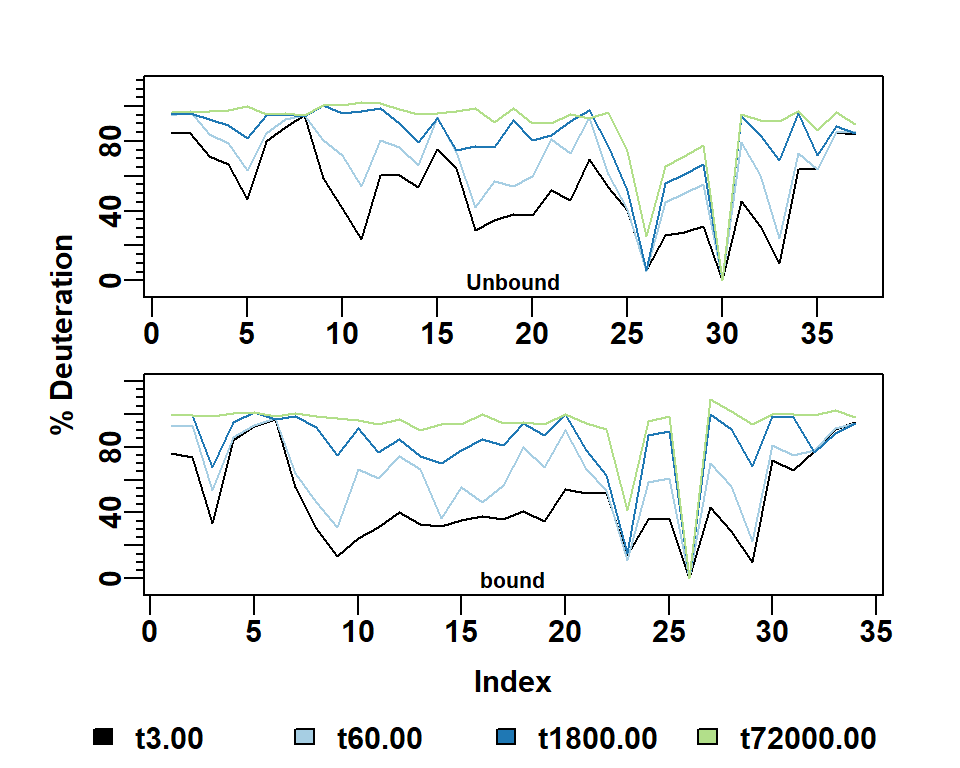

```r
## average procent deuteration in timecourse
plots_av_tcourse(tc_aP, replicates = 3)
```

[output not shown]

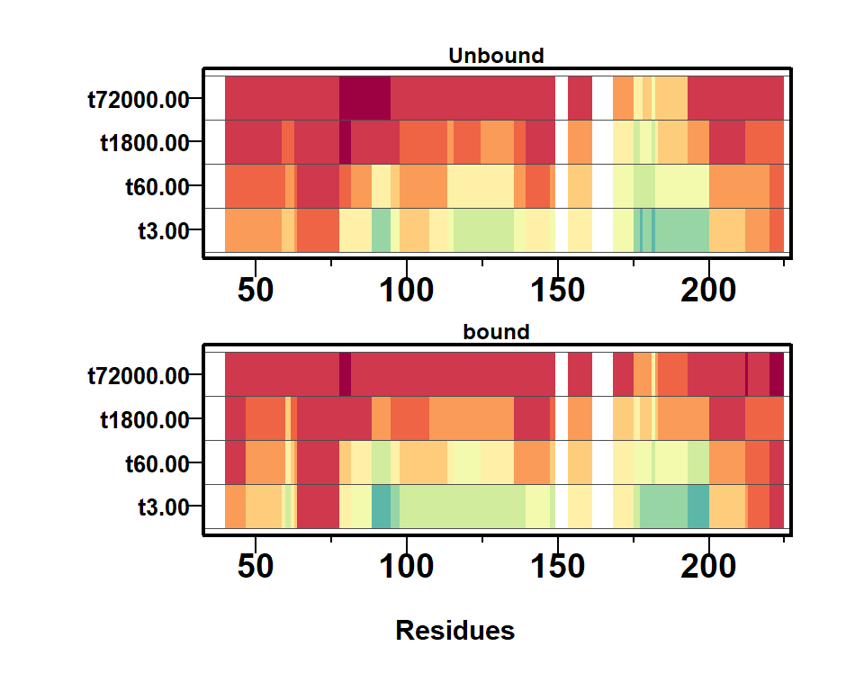

[output not shown]

[figure not shown]

```r
###average heat map for timecourses
plot_heat_map_tc(tc_aP, replicates=3)
```

### Robot Plots

The robot plots are a modification of the butterfly plots. The main difference is that while in the butterfly plots peptides were depicted as a single dot in the middle of the peptide, in robot plot peptides, the whole peptide length is drawn. This replaces butterfly plots’ nice curves with hard edges, which could not be called a delicate butterfly but rather the clinical look of a robotic machine.

The robot plots choose only significant peptides to be drawn. If the peptide is significant in one timepoint, it will be drawn at all time-points, but only significantly different peptides will be colored. The robot plots compare two different data sets: one is drawn above the x-axis, the other below the x-axis.

```r
###load data
library(HDXBoxeR)
file_nm<-system.file("extdata", "All_results_table.csv", package = "HDXBoxeR")
## input for timecourses for procent deuteration and uptake
tc_a<-output_tc(filepath = file_nm)
```

```
#> Protein.States used: Unbound bound
#>
#> Deut.times used: 3.00s 60.00s 1800.00s 72000.00s
#>
#> Number of replicates used: 3
#>
#> no csv file written
```

```r
tc_aP<-output_tc(filepath = file_nm, percent=TRUE)
```

```
#> Protein.States used: Unbound bound
#>
#> Deut.times used: 3.00s 60.00s 1800.00s 72000.00s
#>
#> Number of replicates used: 3
#>
#> no csv file written
```

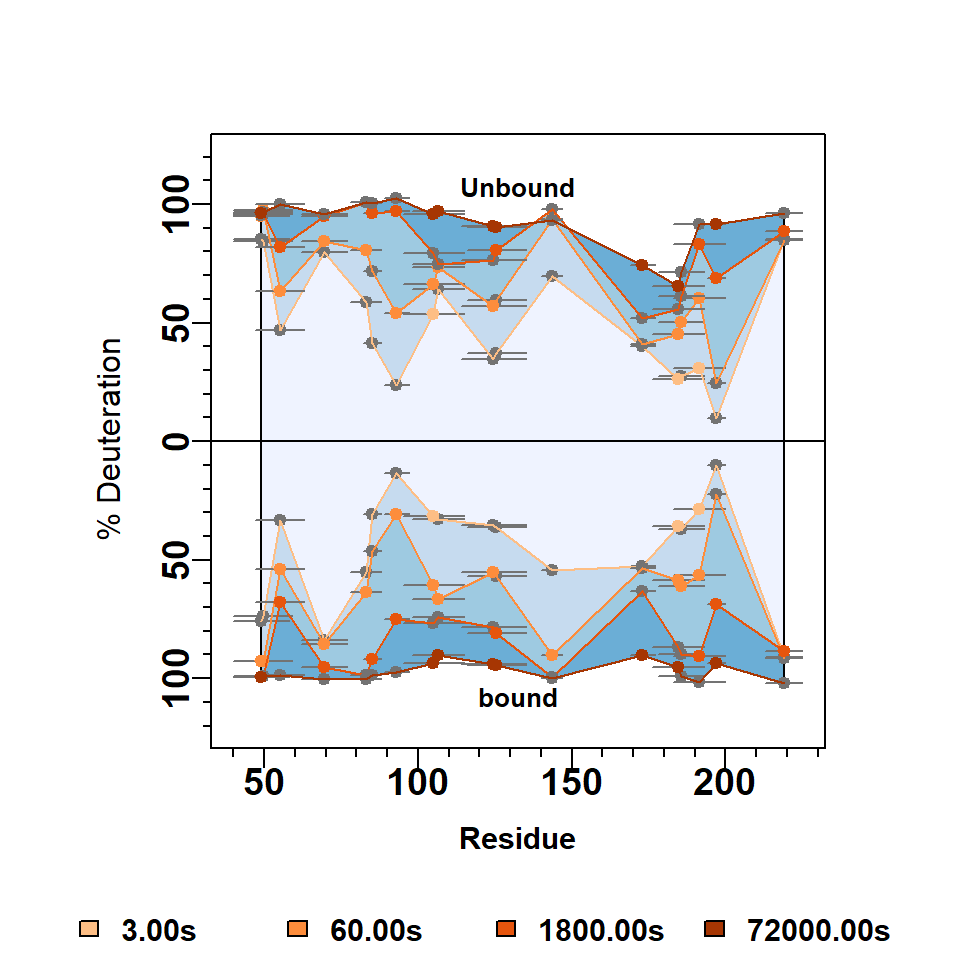

```r
###All peptides drawn
robot_plot_All(thP = tc_aP, th=tc_a)
```

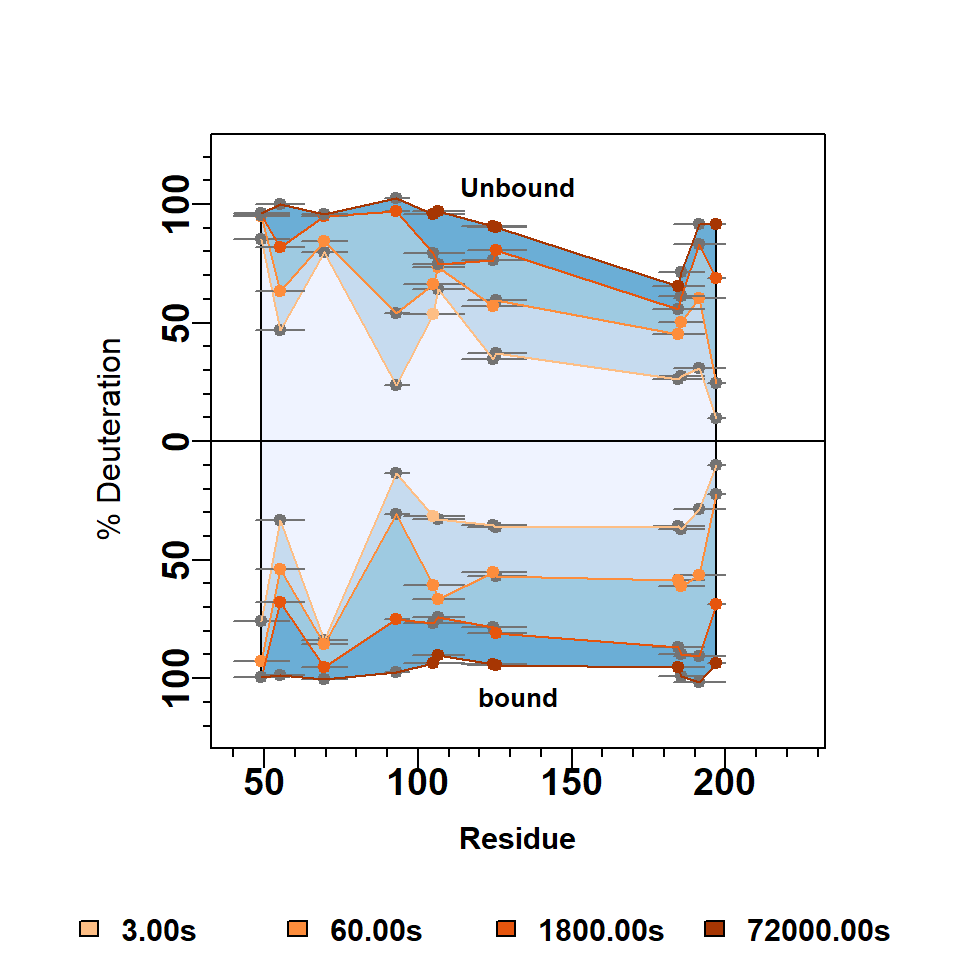

```r
###USe more stingent parameters to have less peptides drawn. CI_factor is a factor that modifies (multiplicate) Critial interval.
robot_plot_All(thP = tc_aP, th=tc_a, pv_cutoff=0.005, replicates = 3)
```

If the robot plots are too crowded, we recommend removing peptides from the robot plot by making the p-value and critical interval more stringent. However, even then, some areas of the plot are too crowded, so manual removal of peptides is necessary to prepare a final plot. To determine which peptides should be removed (or kept), we recommend first looking at the plot and then running the `robot_indexes_df()` function, which returns all significant peptides in the set. After that, one should choose indexes that the user wants to keep and run the `robot_2states_indexes()` function. A note for all these functions: only two states of the proteins should be given, not the whole sets (parameter `states`).

```
#> Protein.States used: Unbound bound
#>
#> Deut.times used: 3.00s 60.00s 1800.00s 72000.00s
#>
#> Number of replicates used: 3
#>
#> no csv file written
#> Protein.States used: Unbound bound
#>
#> Deut.times used: 3.00s 60.00s 1800.00s 72000.00s
#>
#> Number of replicates used: 3
#>
#> no csv file written
#>    nb Start End               Sequence Charge
#> 1   1    40  58    GPLGSKAVVPGPAEHPLQY      2
#> 3   2    47  63      VVPGPAEHPLQYNYTFW      2
#> 4   3    62  77       FWYSRRTPGRPTSSQS      3
#> 9   4    89  97              ASVEQFWRF      2
#> 11  5    95 115  WRFYSHMVRPGDLTGHSDFHL      3
#> 12  6    98 115     YSHMVRPGDLTGHSDFHL      2
#> 14  7   114 135 HLFKEGIKPMWEDDANKNGGKW      3
#> 16  8   116 135   FKEGIKPMWEDDANKNGGKW      3
#> 23  9   176 193     QEDIISIWNKTASDQATT      2
#> 24 10   178 193       DIISIWNKTASDQATT      2
#> 27 11   183 200     WNKTASDQATTARIRDTL      2
#> 28 12   194 200                ARIRDTL      2
```

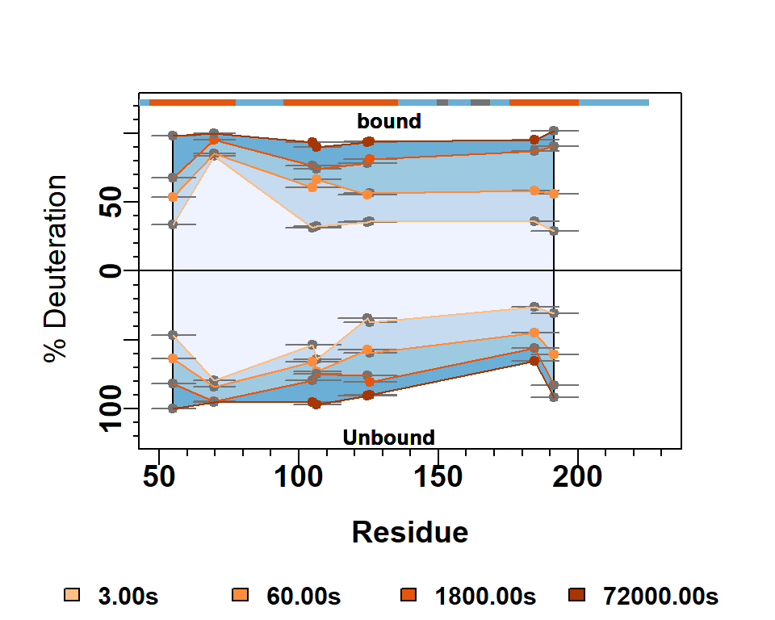